# NPS Simulations - Power Cheat Sheet

Stephanie Chen

2023-03-21

### What is statistical power?

Power is the probability of finding a statistically significant effect *if there is an effect to be found.* Sometimes a product launch, process change, or marketing campaign will have a positive (or negative) effect on the overall population, but our sample may fail to pick that up. If our sample size is too small, our statistical tests have a higher risk of returning *false negatives* - that is, they say we didn’t have an impact when in fact we did. We can avoid this scenario by committing to larger sample sizes before running statistical analyses to test the impact of our work.

### Sample size cheat sheets

These cheat sheet tables are intended to help researchers estimate what sort of sample size they might need to detect differences between groups with 80% power, 70% power, and 60% power. Higher power means there’s a higher chance you will pick up on an effect if it’s there, and lower power means there’s a higher risk you will miss an effect if it’s there.

I *ballparked* suggested sample sizes based on the simulation results. You can determine the sample size needed to detect an increase in NPS based on:

1. how confident you want to be that you didn’t miss anything (e.g., 80% certain I caught it)
2. the baseline or control NPS score
3. how much you think it increased by (I simulated 5 points and 10 points)

**Example**: If you think a really big customer service change could increase company-level NPS by 5 points, and the baseline NPS is 60, you’d need about 4,250 NPS survey respondents in the baseline group and 4,250 survey respondents in the treatment group to detect that 5 point increase in the population 80% of the time.

[figure not shown]

When you can’t get a powerful sample to detect the lift you expect, you could at least rule out that you have tanked NPS with your launch or product.

For different baseline amounts, I found the sample size needed to be somewhat sure we didn’t tank NPS. I simulated a 20 point drop and a 40 point drop with different baselines. Generally, the sample size needed to be 60, 70, and 80% confident that you didn’t tank NPS is smaller.

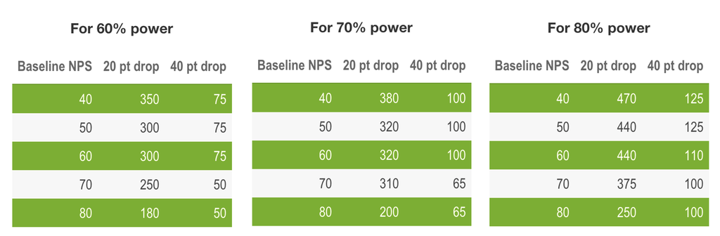

### Simulation Results Plot

Below are plotted results of the simulations I ran, and in the sections after that I have the actual simulation code.

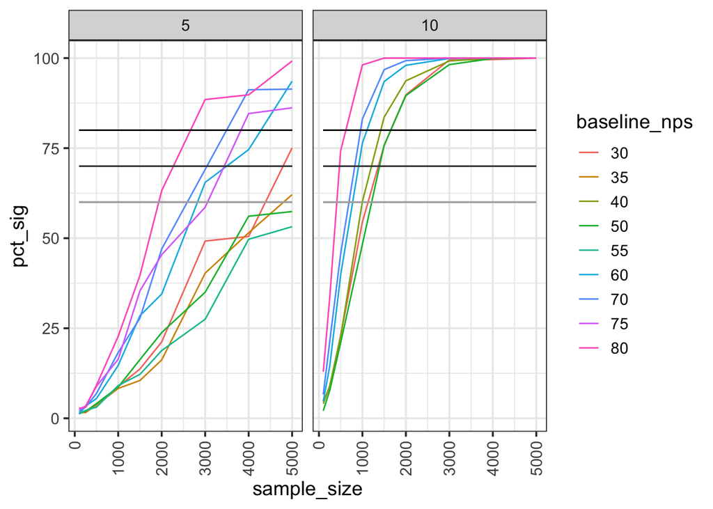

For big effects in NPS, sample sizes don’t need to be so large. Below you can see % of the time we’d get significant results if NPS dropped by 20 points (left) or 40 points (right), as sample sizes increases (x-axis) and depending on different baseline NPS values (colored lines).

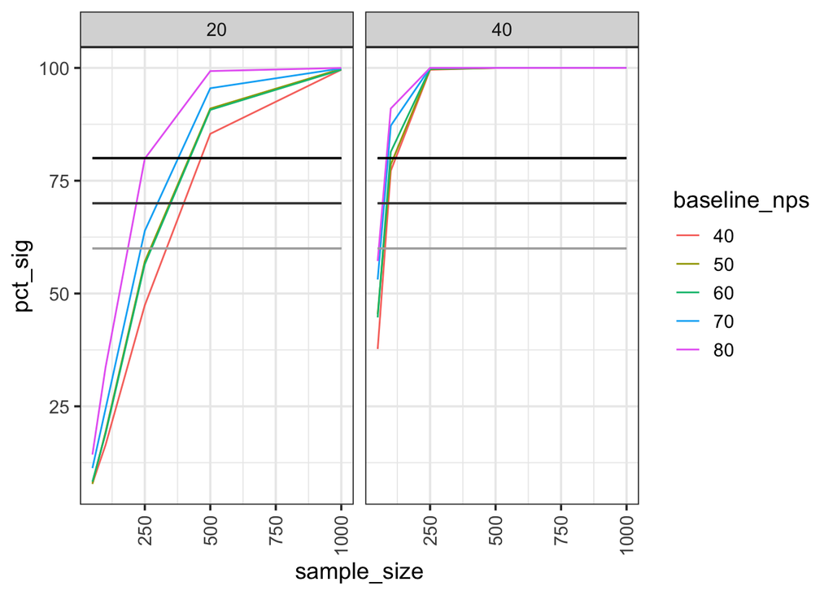

### Simulation code

Step 1: Create the hypothetical “populations” that we will sample from and compute sample NPS.

Step 2: Write functions to take samples of specified sizes from specified populations, compute the NPS score and 95% CI.

Step 3: Write functions to take two samples from 2 populations, get NPS and 95% CI, and flag the cases where the difference is stat sig.

Step 4: Iterate through the various hypothetical populations and look at % of time we (rightfully) detect differences vs. not.

#### Pre-work

**How NPS looks for different distributions**

I will vary the NPS score of the population itself. NPS can be varied by changing the % promoters, % detractors, or both. I won’t simulate every potential population but will test some groups based on how we typically see NPS distributed for our main surveys.

This visual shows just how much more sensitive NPS is when there are fewer shares of passives vs. a greater share of passives.

You can also see what the NPS would be depending on % of promoters and the distribution. For example, if 50% of respondents are promoters, the NPS is 25 if the split is equal, 17 if they’re mostly detractors, and 33 if they’re mostly passive.

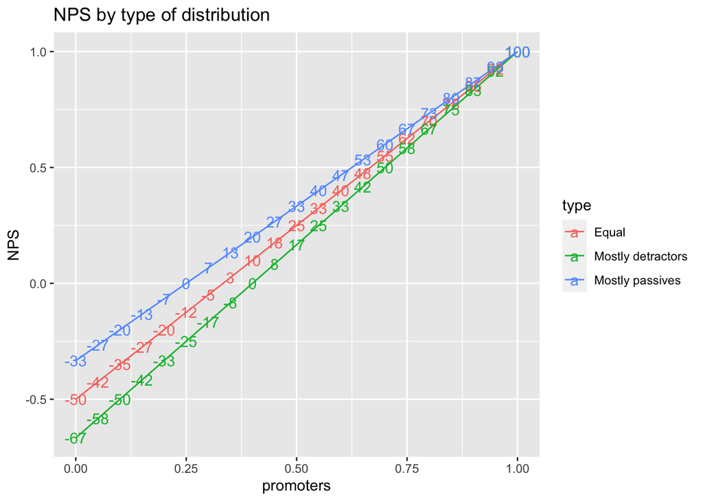

### Actual simulation code

**Creating the population**

I will simulate populations based on an even split between detractors and passives, since this is not uncommon in the real data that we work with. But keep in mind from the analyses that it is possible the results change when the distribution isn’t split that way.

```r
#set population to 50k. Can re-do simulation with different sizes if needed.
pop_size <- 50000

#set number of iterations you want for your simulations
times <- 1000

#sample sizes to test

#original amount

#sample_sizes <- c(50, 100, 250, 500, 1000)

#sample_sizes <- c(100, 250, 500, 1000, 1500, 2000)

#sample_sizes <- c(100, 250, 500, 1000, 1500, 2000, 3000, 4000, 5000)
```

```r
#this function lets you know what the proportion of promoters, passives, and detractors should be for a given NPS score, ASSUMING THAT the detractors and passives are split (which is not always true in real life)

population_function <- function(nps_value) {
  promoters <- (nps_value * 2 + 1)/3
  detractors <- (1 - promoters)/2

  return(data.frame(promoters = promoters,
                    detractors = detractors))
}

p90 <- c(rep("Promoter", .934 * pop_size),
         rep("Passive", .033 * pop_size),
         rep("Detractor", .033 * pop_size))

p85 <- c(rep("Promoter", .9 * pop_size),
         rep("Passive", .05 * pop_size),
         rep("Detractor", .05 * pop_size))

p80 <- c(rep("Promoter", .87 * pop_size),
         rep("Passive", .06 * pop_size),
         rep("Detractor", .07 * pop_size))

p75 <- c(rep("Promoter", .835 * pop_size),
         rep("Passive", .0825 * pop_size),
         rep("Detractor", .0825 * pop_size))

p70 <- c(rep("Promoter", .8 * pop_size),
         rep("Passive", .1 * pop_size),
         rep("Detractor", .1 * pop_size))


p65 <- c(rep("Promoter", .7667 * pop_size),
         rep("Passive", (0.1166666667 * pop_size) - 1),
         rep("Detractor", 0.11667 * pop_size))


p60 <- c(rep("Promoter", .73 * pop_size),
         rep("Passive", .135 * pop_size),
         rep("Detractor", .135 * pop_size))

p55 <- c(rep("Promoter", .70 * pop_size),
         rep("Passive", .15 * pop_size),
         rep("Detractor", .15 * pop_size))

p50 <- c(rep("Promoter", .668 * pop_size),
         rep("Passive", .166 * pop_size),
         rep("Detractor", .166 * pop_size))



p40 <- c(rep("Promoter", .6 * pop_size),
         rep("Passive", .2 * pop_size),
         rep("Detractor", .2 * pop_size))



p35 <- c(rep("Promoter", .5666 * pop_size),
         rep("Passive", .2167 * pop_size),
         rep("Detractor", .2167 * pop_size))


p30 <- c(rep("Promoter", .53 * pop_size),
         rep("Passive", .235 * pop_size),
         rep("Detractor", .235 * pop_size))


p20 <- c(rep("Promoter", (.4667 * pop_size - 1)),
         rep("Passive", .266667 * pop_size),
         rep("Detractor", .266667 * pop_size))

p10 <- c(rep("Promoter", .4 * pop_size),
         rep("Passive", .3 * pop_size),
         rep("Detractor", .3 * pop_size))

p0 <- c(rep("Promoter", .33333333 * pop_size + 1),
         rep("Passive", .3333333 * pop_size),
         rep("Detractor", .3333333 * pop_size + 1))
```

Then I wrote some functions to do sampling and computing NPS scores, 95% CI, and then flagging whether sampled results from 2 populations is significant.

```r
nps <- function(x) {
  step1 <- length(x[x == "Promoter"])/length(x)
  step2 <- length(x[x == "Detractor"])/length(x)
  nps <- step1 - step2
  output <- data.frame(nps = nps,
                       promoter = step1,
                       detractor = step2,
                       passive = 1 - step1 - step2,
                       count = length(x))
  return(output)
}


nps_table <- function(x) {
  step1 <- data.frame(nps = nps(x)$nps,
              Promoter = nps(x)$promoter,
              Passive = nps(x)$passive,
              Detractor = nps(x)$detractor,
              Total_Count = nps(x)$count)

  #get variance
  step1$var <- (1 - step1$nps)**2 * step1$Promoter +
    (0 - step1$nps)**2 * step1$Passive +
    (-1 - step1$nps)**2 * step1$Detractor

  #standard dev, se, and 95% CI bounds
  step1 <- step1 %>%
    mutate(sd = sqrt(var)) %>%
    mutate(se = sd / sqrt(Total_Count)) %>%
    mutate(ci95 = 1.96 * se)

  #make percents instead of proportion
  step1$nps <- round(step1$nps* 100, 0)
  step1$lower <- step1$nps - round(step1$ci95 * 100, 2)
  step1$upper <- step1$nps + round(step1$ci95 * 100, 2)

  return(step1 %>%
           select(nps,
                  lower,
                  upper))
}








samp <- function(data_set, sample_size){
  output <- sample(data_set, sample_size, replace = F)
  return(output)
}

sample_function <- function(data_set, sample_size, num_iterations) {

  output <- replicate(num_iterations, samp(data_set, sample_size))
  output <- data.frame(
    output
  )

  return(output)
}

# You will use sample functions to create datasets and then use the nps_all function to get the final estimates
# This way we're running shorter steps and can break it down if needed rather than having 1 long mega function
test_matrix <- sample_function(p30, 5, 10)


#get median nps for all the samples you took, as well as the 95% confidence interval computed from formula
all_nps <- function(data_set) {
  num_iterations <- ncol(data_set)
  output <- data.frame(nps = NA,
                       lower = NA,
                       upper = NA)

for (column in 1:num_iterations) #will do this for every column in the simulated dataset we're taking in
    output <- rbind(output, nps_table(data_set[,column]))

  final <- output[is.na(output$nps) == F,]
  return(final)
}


#Cbind related datasets, and create a flag for when they are significantly different (this works for increases in NPS)
comb <- function(a, b) {
  result <- cbind(a, b)

  colnames(result) <- c('nps',
                      'lower',
                      'upper',
                      'nps2',
                      'lower2',
                      'upper2')
  result$lower_is_lower <- ifelse(result$nps2 - result$nps > 0, 1, 0)
  result$sig <- 0
  result$sig[result$lower_is_lower == 1] <- ifelse(result$upper[result$lower_is_lower == 1] >
                                                     result$lower2[result$lower_is_lower == 1], 0, 1)

  return(result)
}


comb_drop <- function(a, b) {
  result <- cbind(a, b)

  colnames(result) <- c('nps',
                      'lower',
                      'upper',
                      'nps2',
                      'lower2',
                      'upper2')
  result$lower_is_lower <- ifelse(result$nps2 - result$nps < 0, 1, 0)
  result$sig <- 0
  result$sig[result$lower_is_lower == 1] <- ifelse(result$lower[result$lower_is_lower == 1] <
                                                     result$upper2[result$lower_is_lower == 1], 0, 1)

  return(result)
}
```

Create the re-sampled simulations and save the results file so you can read it in and not have to re-run every time.

```r
dataset1 <- cbind(p30, p40, p50, p60, p70, p80, #increase of 10
                  p30, p35, p50, p55, p60, p70, p75, p80) #increase of 5
dataset2 <- cbind(p40, p50, p60, p70, p80, p90, #increase of 10
                  p35, p40, p55, p60, p65, p75, p80, p85) #increase of 5

pct_sig <- data.frame(pct_sig = NA,
                      sample_size = NA,
                      baseline_nps = NA,
                      comparison_nps = NA)

for(i in 1:length(sample_sizes))
  for(col in 1:14) #number of columns in dataset1, dataset2
     pct_sig <- rbind(pct_sig,
                      comb(
        all_nps(
          sample_function(dataset1[,col], sample_sizes[i], times)),
        all_nps(sample_function(dataset2[,col], sample_sizes[i], times))
      ) %>%
        summarise(pct_sig = round(mean(sig) * 100, 1),
                  sample_size = sample_sizes[i],
                  baseline_nps = colnames(dataset1)[col],
                  comparison_nps = colnames(dataset2)[col]))


pct_sig1 <- pct_sig %>%
  filter(is.na(pct_sig) == F)

pct_sig1$baseline_nps <- sub("p", "", pct_sig1$baseline_nps)
pct_sig1$comparison_nps <- sub("p", "", pct_sig1$comparison_nps)
pct_sig1$nps_increase <- as.numeric(pct_sig1$comparison_nps) - as.numeric(pct_sig1$baseline_nps)


#write.csv(pct_sig1, file = "powersim_1000.csv")
```

I also ran a version for sample sizes needed to detect big effects, which are rare. This would at least allow us to rule out major breakages/tanking of NPS with smaller sample sizes even if it is not feasible to wait for enough power to test for NPS lift.

```r
dataset1 <- cbind(p80, p70, p60, p50, p40, #drops of 40
                  p80, p70, p60, p50, p40) #drops of 20
dataset2 <- cbind(p40, p30, p20, p10, p0,  #drops of 40
                  p60, p50, p40, p30, p20) #drops of 20

pct_sig <- data.frame(pct_sig = NA,
                      sample_size = NA,
                      baseline_nps = NA,
                      comparison_nps = NA)

for(i in 1:length(sample_sizes))
  for(col in 1:10) #number of columns in dataset1, dataset2
     pct_sig <- rbind(pct_sig,
                      comb_drop(
        all_nps(
          sample_function(dataset1[,col], sample_sizes[i], times)),
        all_nps(sample_function(dataset2[,col], sample_sizes[i], times))
      ) %>%
        summarise(pct_sig = round(mean(sig) * 100, 1),
                  sample_size = sample_sizes[i],
                  baseline_nps = colnames(dataset1)[col],
                  comparison_nps = colnames(dataset2)[col]))

pct_sig1 <- pct_sig %>%
  filter(is.na(pct_sig) == F)

pct_sig1$baseline_nps <- sub("p", "", pct_sig1$baseline_nps)
pct_sig1$comparison_nps <- sub("p", "", pct_sig1$comparison_nps)
pct_sig1$nps_drop <- as.numeric(pct_sig1$baseline_nps) - as.numeric(pct_sig1$comparison_nps)

#write.csv(pct_sig1, file = "powersim_1000_drop.csv")
```